# CLP2 Baseline Analysis - Rubrics (Sample Data Exercise)

Manuel Kiewisch, the World Cocoa Foundation (manuel.kiewisch@worldcocoa.org)

## Purpose

- Preparation of CLP2 analysis
- Explanation of the analysis procedure for reproduction
- Documentation of analysis procedure for learning

## Data

- based on dummy data received on: 13/04/2015, from: IPSOS, Jill Humble
- dummy data available internally on WCF shared drive:  
  {G:\Shared\6 - West Africa\Cocoa Livelihoods Program\CLP Phase II\M&E\Baseline\Analysis\CLP2 Dummy Data}

## Data Preparation

File Names:  
- Household Survey dummy data: newHhVisit.SAV  
- Food crop visit dummy data: newCropVisit.SAV  
- Cocoa visit dummy data: newFarmVisit.SAV

### Conversion to R data frames

```r
library(foreign)
library(car)
library(dplyr)
library(ggplot2)
#setwd("G:\\6 - West Africa\\Cocoa Livelihoods Program\\CLP Phase II\\M&E\\Baseline\\Analysis\\CLP2 Dummy Data")
setwd("C:\\Users\\ElitebookHP\\Desktop\\R_Work\\CLP2 Dummy Data")
#setwd("C:\\Users\\Manuel.Kiewisch\\Desktop\\R_Work\\CLP2 Dummy Data")
hhsurvey <- read.spss("newHhVisit.SAV",to.data.frame=TRUE,use.value.labels = FALSE)
foodvisit <- read.spss("newCropVisit.SAV",to.data.frame=TRUE,use.value.labels = FALSE)
cocoavisit <- read.spss("newFarmVisit.SAV",to.data.frame=TRUE,use.value.labels = FALSE)
colnames(cocoavisit) <- toupper(colnames(cocoavisit))
colnames(foodvisit) <- toupper(colnames(foodvisit))
colnames(hhsurvey) <- toupper(colnames(hhsurvey))
```

## Cocoa Farm Visit Rubrics

**changelog: all ^S_FID1$ variables are now ^S_FID$**

### Pest Management

```r
cocoavars1 <- grep("^S_FID$|^B2_.|^E1_.|^E2_.|^E3_.", names(cocoavisit), value=TRUE) #select only pest management variables
pestgap <- cocoavisit[cocoavars1] #data table for pest GAP
cocoavars1full <- grep("^E1_.|^E2_.|^E3_.", names(pestgap), value=TRUE) #select only countable score variables
pestgap[grep("^E1_.",cocoavars1,value=TRUE)] <- recode(unlist(pestgap[grep("^E1_.",cocoavars1,value=TRUE)]),"1=1;2=0;else=NA") #recoding values
pestgap[grep("^E2_.",cocoavars1,value=TRUE)] <- recode(unlist(pestgap[grep("^E2_.",cocoavars1,value=TRUE)]),"1=1;2=0;else=NA") #recoding values
pestgap[grep("^E3_.",cocoavars1,value=TRUE)] <- recode(unlist(pestgap[grep("^E3_.",cocoavars1,value=TRUE)]),"1=1;2=0;else=NA") #recoding values
pestgap$NAcheck <- ifelse((apply(pestgap[grep("^E1_.",cocoavars1,value=TRUE)],1,function(x) length(which(is.na(x)))) ==
apply(pestgap[grep("^E2_.",cocoavars1,value=TRUE)],1,function(x) length(which(is.na(x))))) & (apply(pestgap[grep("^E1_.",cocoavars1,value=TRUE)],1,function(x) length(which(is.na(x)))) ==
apply(pestgap[grep("^E3_.",cocoavars1,value=TRUE)],1,function(x) length(which(is.na(x))))),"1",NA) #checks that for every observation component the same number of trees have been checked
pestgap$scoreE1 <- (rowSums(pestgap[grep("^E1_.",cocoavars1full,value=TRUE)],na.rm=TRUE)) / apply(pestgap[grep("^E1_.",cocoavars1full,value=TRUE)],1,function(x) length(which(!is.na(x))))  #scores per entry and category, ignoring NA
pestgap$scoreE2 <- (rowSums(pestgap[grep("^E2_.",cocoavars1full,value=TRUE)],na.rm=TRUE)) / apply(pestgap[grep("^E2_.",cocoavars1full,value=TRUE)],1,function(x) length(which(!is.na(x))))  #scores per entry and category, ignoring NA
pestgap$scoreE3 <- (rowSums(pestgap[grep("^E3_.",cocoavars1full,value=TRUE)],na.rm=TRUE)) / apply(pestgap[grep("^E3_.",cocoavars1full,value=TRUE)],1,function(x) length(which(!is.na(x))))  #scores per entry and category, ignoring NA
pestgap$evaluation <- ifelse(is.na(pestgap$NAcheck),NA,ifelse(apply(pestgap[c("scoreE1","scoreE2","scoreE3")], 1, max) > 0.2,"No Evidence of Adoption",
                             ifelse(apply(pestgap[c("scoreE1","scoreE2","scoreE3")], 1, max) > 0.1 & apply(pestgap[c("scoreE1","scoreE2","scoreE3")], 1, max) <= 0.2,"Evidence of Minimum Adoption",
                             ifelse(apply(pestgap[c("scoreE1","scoreE2","scoreE3")], 1, max) > 0.05 & apply(pestgap[c("scoreE1","scoreE2","scoreE3")], 1, max) <= 0.1,"Evidence of Good Adoption",
                                    ifelse(apply(pestgap[c("scoreE1","scoreE2","scoreE3")], 1, max) <= 0.05,"Evidence of Excellent Adoption","NA"))))) #evaluation of all criteria together
pestgapfinal <- (pestgap[c("S_FID","NAcheck","scoreE1","scoreE2","scoreE3","evaluation")]) #filter only cases for cass only
colnames(pestgapfinal)[1] <- "C1"
write.table(pestgapfinal, "CocoaFarm_pestManagement.txt", sep="\t")
print(head(pestgapfinal))
```

```
##        C1 NAcheck   scoreE1    scoreE2   scoreE3
## 1  333546       1 0.2083333 0.54166667 0.5000000
## 2  903764       1 0.0000000 0.07407407 0.7407407
## 3 1739243       1 0.0000000 0.00000000 0.0000000
## 4 1846372       1 0.2666667 0.56666667 0.4333333
## 5 2014877       1 0.0000000 0.04166667 0.0000000
## 6 2034433       1 0.2121212 0.09090909 0.8181818
##                       evaluation
## 1        No Evidence of Adoption
## 2        No Evidence of Adoption
## 3 Evidence of Excellent Adoption
## 4        No Evidence of Adoption
## 5 Evidence of Excellent Adoption
## 6        No Evidence of Adoption
```

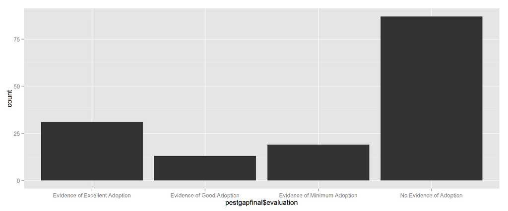

```
## [[1]]
## [[1]][[1]]
##    y count x ndensity ncount  density PANEL group ymin ymax xmin xmax
## 1 31    31 1        1      1 1.111111     1     1    0   31 0.55 1.45
## 2 13    13 2        1      1 1.111111     1     2    0   13 1.55 2.45
## 3 19    19 3        1      1 1.111111     1     3    0   19 2.55 3.45
## 4 87    87 4        1      1 1.111111     1     4    0   87 3.55 4.45
```

```r
ifelse(nrow(pestgapfinal)==0 | all(is.na(pestgapfinal$evaluation)),"No Tree Data In Dataset, or all values <NA>",print(
ggplot(data=pestgapfinal, aes(pestgapfinal$evaluation)) + geom_histogram()))
```

### Weed Management

```r
cocoavars2 <- grep("^S_FID$|^G1_.|^G3_.", names(cocoavisit), value=TRUE) #select only weed management variables
weedgap <- cocoavisit[cocoavars2] #data table for weed GAP
cocoavars2full <- grep("^G1_.|^G3_.", names(weedgap), value=TRUE) #select only countable score variables
weedgap[grep("^G1_.",cocoavars2,value=TRUE)] <- recode(unlist(weedgap[grep("^G1_.",cocoavars2,value=TRUE)]),"1=1;2=0.5;3=0;else=NA") #recoding values
weedgap[grep("^G3_.",cocoavars2,value=TRUE)] <- recode(unlist(weedgap[grep("^G3_.",cocoavars2,value=TRUE)]),"1=1;2=0;else=NA") #recoding values
weedgap$NAcheck <- ifelse((apply(weedgap[grep("^G1_.",cocoavars2,value=TRUE)],1,function(x) length(which(is.na(x)))) ==
apply(weedgap[grep("^G3_.",cocoavars2,value=TRUE)],1,function(x) length(which(is.na(x))))),"1",NA) #checks that for every observation component the same number of trees have been checked
weedgap$scoreG1 <- (rowSums(weedgap[grep("^G1_.",cocoavars2full,value=TRUE)],na.rm=TRUE)) / apply(weedgap[grep("^G1_.",cocoavars2full,value=TRUE)],1,function(x) length(which(!is.na(x))))  #scores per entry and category, ignoring NA
weedgap$scoreG3 <- (rowSums(weedgap[grep("^G3_.",cocoavars2full,value=TRUE)],na.rm=TRUE)) / apply(weedgap[grep("^G3_.",cocoavars2full,value=TRUE)],1,function(x) length(which(!is.na(x))))  #scores per entry and category, ignoring NA
weedgap$evaluation <- ifelse(is.na(weedgap$NAcheck),NA,ifelse(apply(weedgap[c("scoreG1")], 1, max) > 0.5,"No Evidence of Adoption",
                             ifelse(apply(weedgap[c("scoreG1")], 1, max) > 0.3 & apply(weedgap[c("scoreG1")], 1, max) <= 0.5,"Evidence of Minimum Adoption",
                             ifelse(apply(weedgap[c("scoreG1")], 1, max) > 0.15 & apply(weedgap[c("scoreG1")], 1, max) <= 0.3,"Evidence of Good Adoption",
                                    ifelse(apply(weedgap[c("scoreG1")], 1, max) <= 0.15,"Evidence of Excellent Adoption","NA"))))) #evaluation of all criteria together
weedgap$evaluationplus <- ifelse(is.na(weedgap$NAcheck),NA,ifelse(apply(weedgap[c("scoreG3")], 1, max) >= 0.5,"Additionaly Evidence of Ground-Cover","No Additional Evidence of Ground-Cover")) #evaluation extra criteria
weedgapfinal <- (weedgap[c("S_FID","NAcheck","scoreG1","scoreG3","evaluation","evaluationplus")]) #filter only cases for cass only
colnames(weedgapfinal)[1] <- "C1"
write.table(weedgapfinal, "CocoaFarm_weedManagement.txt", sep="\t")
print(head(weedgapfinal))
```

```
##        C1 NAcheck   scoreG1 scoreG3                   evaluation
## 1  333546       1 0.3333333       1 Evidence of Minimum Adoption
## 2  903764       1 0.1666667       0    Evidence of Good Adoption
## 3 1739243       1 1.0000000       1      No Evidence of Adoption
## 4 1846372       1 0.1666667       1    Evidence of Good Adoption
## 5 2014877       1 0.5000000       1 Evidence of Minimum Adoption
## 6 2034433       1 0.6666667       1      No Evidence of Adoption
##                           evaluationplus
## 1   Additionaly Evidence of Ground-Cover
## 2 No Additional Evidence of Ground-Cover
## 3   Additionaly Evidence of Ground-Cover
## 4   Additionaly Evidence of Ground-Cover
## 5   Additionaly Evidence of Ground-Cover
## 6   Additionaly Evidence of Ground-Cover
```

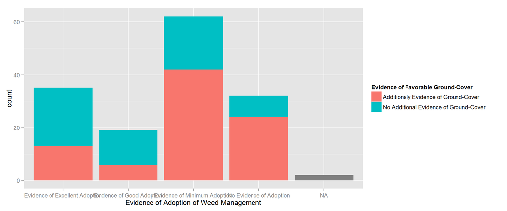

```
## [[1]]
## [[1]][[1]]
##      fill  y count x ndensity ncount  density PANEL group ymin ymax xmin
## 1 #F8766D 13    13 1        1      1 1.111111     1     1    0   13 0.55
## 2 #00BFC4 35    22 1        1      1 1.111111     1     5   13   35 0.55
## 3 #F8766D  6     6 2        1      1 1.111111     1     2    0    6 1.55
## 4 #00BFC4 19    13 2        1      1 1.111111     1     6    6   19 1.55
## 5 #F8766D 42    42 3        1      1 1.111111     1     3    0   42 2.55
## 6 #00BFC4 62    20 3        1      1 1.111111     1     7   42   62 2.55
## 7 #F8766D 24    24 4        1      1 1.111111     1     4    0   24 3.55
## 8 #00BFC4 32     8 4        1      1 1.111111     1     8   24   32 3.55
## 9  grey50  2     2 5        1      1 1.111111     1     9    0    2 4.55
##   xmax
## 1 1.45
## 2 1.45
## 3 2.45
## 4 2.45
## 5 3.45
## 6 3.45
## 7 4.45
## 8 4.45
## 9 5.45
```

```r
ifelse(nrow(weedgapfinal)==0 | all(is.na(weedgapfinal$evaluation)),"No Weed Data In Dataset, or all values <NA>",print(
ggplot(data=weedgapfinal, aes(weedgapfinal$evaluation)) + geom_bar(aes(fill=evaluationplus)) + xlab("Evidence of Adoption of Weed Management") + labs(fill='Evidence of Favorable Ground-Cover')))
```

### Cocoa Tree Pruning

```r
cocoavars3 <- grep("^S_FID$|^B2_.|^C1_.|^C2_.|^C3_.|^D2_.|^D3_.|^D4_.|^D1_.", names(cocoavisit), value=TRUE) #select only prun management variables
prungap <- cocoavisit[cocoavars3] #data table for prun GAP
cocoavars3full <- grep("^B2_.|^C1_.|^C2_.|^C3_.|^D2_.|^D3_.|^D4_.|^D1_.", names(prungap), value=TRUE) #select only countable score variables
prungap[grep("^C1_.",cocoavars3,value=TRUE)] <- recode(unlist(prungap[grep("^C1_.",cocoavars3,value=TRUE)]),"1=0.5;2=0;3=1;else=NA") #recoding values
prungap[grep("^C2_.",cocoavars3,value=TRUE)] <- recode(unlist(prungap[grep("^C2_.",cocoavars3,value=TRUE)]),"1=0.5;2=0;3=1;else=NA") #recoding values
prungap[grep("^C3_.",cocoavars3,value=TRUE)] <- recode(unlist(prungap[grep("^C3_.",cocoavars3,value=TRUE)]),"1=1;2=0;3=1;else=NA") #recoding values
prungap[grep("^D1_.",cocoavars3,value=TRUE)] <- recode(unlist(prungap[grep("^D1_.",cocoavars3,value=TRUE)]),"1=1;2=0;else=NA") #recoding values
prungap[grep("^D2_.",cocoavars3,value=TRUE)] <- recode(unlist(prungap[grep("^D2_.",cocoavars3,value=TRUE)]),"1=1;2=0;else=NA") #recoding values
prungap[grep("^D3_.",cocoavars3,value=TRUE)] <- recode(unlist(prungap[grep("^D3_.",cocoavars3,value=TRUE)]),"1=1;2=0;else=NA") #recoding values
prungap[grep("^D4_.",cocoavars3,value=TRUE)] <- recode(unlist(prungap[grep("^D4_.",cocoavars3,value=TRUE)]),"1=1;2=0;else=NA") #recoding values
prungap$NAcheck <- ifelse((apply(prungap[grep("^C1_.|^C2_.|^C3_.",cocoavars3,value=TRUE)],1,function(x) length(which(is.na(x)))) ==
apply(prungap[grep("^D2_.|^D3_.|^D4_.",cocoavars3,value=TRUE)],1,function(x) length(which(is.na(x))))),"1",NA) #checks that for every observation component the same number of trees have been checked
prungap$scoreC <- (rowSums(prungap[grep("^C1_.|^C2_.|^C3_.",cocoavars3full,value=TRUE)],na.rm=TRUE)) / (3 * apply(prungap[grep("^C1_.|^C2_.|^C3_.",cocoavars3full,value=TRUE)],1,function(x) length(which(!is.na(x)))))  #scores per entry and category, ignoring NA
prungap$scoreD <- (rowSums(prungap[grep("^D2_.|^D3_.|^D4_.",cocoavars3full,value=TRUE)],na.rm=TRUE)) / (3 * apply(prungap[grep("^D2_.|^D3_.|^D4_.",cocoavars3full,value=TRUE)],1,function(x) length(which(!is.na(x)))))  #scores per entry and category, ignoring NA
prungap$scoreplus <- (rowSums(prungap[grep("^D1_.",cocoavars3full,value=TRUE)],na.rm=TRUE)) / apply(prungap[grep("^D1_.",cocoavars3full,value=TRUE)],1,function(x) length(which(!is.na(x))))  #scores per entry and category, ignoring NA
prungap$evaluation <- ifelse(is.na(prungap$NAcheck),NA,ifelse(apply(prungap[c("scoreC","scoreD")], 1, max) > 0.3,"No Evidence of Adoption",
                             ifelse(apply(prungap[c("scoreC","scoreD")], 1, max) > 0.2 & apply(prungap[c("scoreC","scoreD")], 1, max) <= 0.3,"Evidence of Minimum Adoption",
                             ifelse(apply(prungap[c("scoreC","scoreD")], 1, max) > 0.1 & apply(prungap[c("scoreC","scoreD")], 1, max) <= 0.2,"Evidence of Good Adoption",
                                    ifelse(apply(prungap[c("scoreC","scoreD")], 1, max) <= 0.1,"Evidence of Excellent Adoption","NA"))))) #evaluation of all criteria together
prungap$evaluationplus <- ifelse(is.na(prungap$NAcheck),NA,ifelse(apply(prungap[c("scoreplus")], 1, max) >= 0.3,"Additionaly Evidence of Recent Pruning","No Additional Evidence of Recent Pruning")) #evaluation extra criteria
prungapfinal <- (prungap[c("S_FID","NAcheck","scoreC","scoreD","scoreplus","evaluation","evaluationplus")]) #filter only cases for cass only
colnames(prungapfinal)[1] <- "C1"
write.table(prungapfinal, "CocoaFarm_pruningManagement.txt", sep="\t")
print(head(prungapfinal))
```

```
##        C1 NAcheck    scoreC     scoreD scoreplus
## 1  333546       1 0.1504630 0.10648148 0.6666667
## 2  903764       1 0.3065844 0.21399177 1.0000000
## 3 1739243       1 0.2638889 0.18055556 1.0000000
## 4 1846372       1 0.2481481 0.17037037 0.6666667
## 5 2014877       1 0.1782407 0.06944444 1.0000000
## 6 2034433       1 0.1397306 0.21548822 1.0000000
##                     evaluation                         evaluationplus
## 1    Evidence of Good Adoption Additionaly Evidence of Recent Pruning
## 2      No Evidence of Adoption Additionaly Evidence of Recent Pruning
## 3 Evidence of Minimum Adoption Additionaly Evidence of Recent Pruning
## 4 Evidence of Minimum Adoption Additionaly Evidence of Recent Pruning
## 5    Evidence of Good Adoption Additionaly Evidence of Recent Pruning
## 6 Evidence of Minimum Adoption Additionaly Evidence of Recent Pruning
```

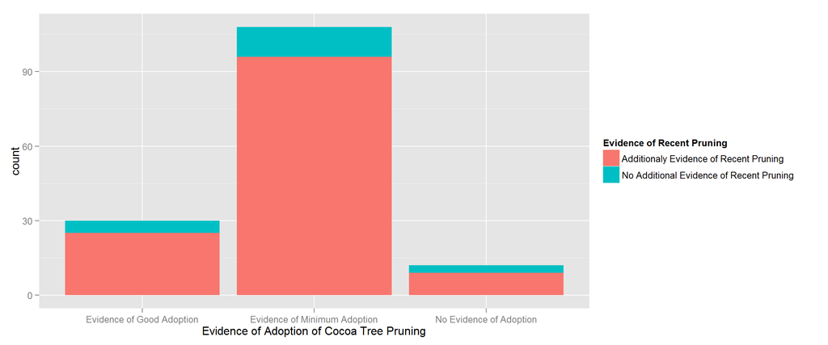

```
## [[1]]
## [[1]][[1]]
##      fill   y count x ndensity ncount  density PANEL group ymin ymax xmin
## 1 #F8766D  25    25 1        1      1 1.111111     1     1    0   25 0.55
## 2 #00BFC4  30     5 1        1      1 1.111111     1     4   25   30 0.55
## 3 #F8766D  96    96 2        1      1 1.111111     1     2    0   96 1.55
## 4 #00BFC4 108    12 2        1      1 1.111111     1     5   96  108 1.55
## 5 #F8766D   9     9 3        1      1 1.111111     1     3    0    9 2.55
## 6 #00BFC4  12     3 3        1      1 1.111111     1     6    9   12 2.55
##   xmax
## 1 1.45
## 2 1.45
## 3 2.45
## 4 2.45
## 5 3.45
## 6 3.45
```

```r
ifelse(nrow(prungapfinal)==0 | all(is.na(prungapfinal$evaluation)),"No Pruning Data In Dataset, or all values <NA>",print(
ggplot(data=prungapfinal, aes(prungapfinal$evaluation)) + geom_bar(aes(fill=evaluationplus)) + xlab("Evidence of Adoption of Cocoa Tree Pruning") + labs(fill='Evidence of Recent Pruning')))
```

### Cocoa Farm Intercropping

**Changelog: allow ^F4_.$ option 4(cannot identify) to be valid to indicate root-crop diveristy**

```r
cocoavars4 <- grep("^S_FID$|^F1_.|^F2_.SUM|^F3_.|^F4_.SUM|^F5_.|^F6_.|^F7_.", names(cocoavisit), value=TRUE) #select only inte management variables
integap <- cocoavisit[cocoavars4] #data table for inte GAP
cocoavars4full <- grep("^F1_.|^F2_.SUM|^F3_.|^F4_.SUM|^F5_.|^F6_.|^F7_.", names(integap), value=TRUE) #select only countable score variables
integap[grep("^F1_.",cocoavars4,value=TRUE)] <- recode(unlist(integap[grep("^F1_.",cocoavars4,value=TRUE)]),"1=1;2=0;else=NA") #recoding values
integap[grep("^F3_.",cocoavars4,value=TRUE)] <- recode(unlist(integap[grep("^F3_.",cocoavars4,value=TRUE)]),"1=1;2=0;else=NA") #recoding values
integap[grep("^F5_.",cocoavars4,value=TRUE)] <- recode(unlist(integap[grep("^F5_.",cocoavars4,value=TRUE)]),"1=1;2=0;else=NA") #recoding values
integap[grep("^F6_.",cocoavars4,value=TRUE)] <- recode(unlist(integap[grep("^F6_.",cocoavars4,value=TRUE)]),"1=1;2=0;else=NA") #recoding values
integap[grep("^F7_.",cocoavars4,value=TRUE)] <- recode(unlist(integap[grep("^F7_.",cocoavars4,value=TRUE)]),"1=1;2=0;else=NA") #recoding values
integap[grep("^F2_.",cocoavars4,value=TRUE)] <- recode(unlist(integap[grep("^F2_.",cocoavars4,value=TRUE)]),"1:11=1;else=NA") #recoding values
integap[grep("^F4_.",cocoavars4,value=TRUE)] <- recode(unlist(integap[grep("^F4_.",cocoavars4,value=TRUE)]),"1:4=1;else=NA") #recoding values
integap$F2_sum <- rowSums(cbind(rowSums(integap[grep("^F2_.SUM_1",cocoavars4,value=TRUE)],na.rm=TRUE) >= 2,rowSums(integap[grep("^F2_.SUM_2",cocoavars4,value=TRUE)],na.rm=TRUE) >= 2,rowSums(integap[grep("^F2_.SUM_3",cocoavars4,value=TRUE)],na.rm=TRUE) >= 2),na.rm=TRUE) #count circles with min.2 fruit tree species
integap$F4_sum <- rowSums(cbind(rowSums(integap[grep("^F4_.SUM_1",cocoavars4,value=TRUE)],na.rm=TRUE) >= 2,rowSums(integap[grep("^F4_.SUM_2",cocoavars4,value=TRUE)],na.rm=TRUE) >= 2,rowSums(integap[grep("^F4_.SUM_3",cocoavars4,value=TRUE)],na.rm=TRUE) >= 2),na.rm=TRUE) #count circles with min.2 root crop species
integap$NAcheck <- ifelse((apply(integap[grep("^F1_.",cocoavars4,value=TRUE)],1,function(x) length(which(is.na(x)))) ==
apply(integap[grep("^F7_.",cocoavars4,value=TRUE)],1,function(x) length(which(is.na(x))))) & (apply(integap[grep("^F1_.|^F3_.",cocoavars4,value=TRUE)],1,function(x) length(which(is.na(x)))) ==
apply(integap[grep("^F5_.|^F6_.",cocoavars4,value=TRUE)],1,function(x) length(which(is.na(x))))),"1",NA) #checks that for every observation component the same number of trees have been checked
integap$score <- (rowSums(integap[grep("^F1_.|^F3_.|^F5_.|^F6_.|^F7_.",cocoavars4full,value=TRUE)],na.rm=TRUE)) / ((apply(integap[grep("^F1_.|^F3_.|^F5_.|^F6_.|^F7_.",cocoavars4full,value=TRUE)],1,function(x) length(which(!is.na(x))))) / 5)  #scores per entry and category, ignoring NA
integap$scoreplus <- (rowSums(integap[c("F2_sum","F4_sum")],na.rm=TRUE)) / 3  #scores average number of circles which had at least 2 observations of each crop type
integap$evaluation <- ifelse(is.na(integap$NAcheck),NA,ifelse(apply(integap["score"], 1, max) == 0,"No Evidence of Adoption",
                             ifelse(apply(integap["score"], 1, max) > 0 & apply(integap["score"], 1, max) <= 1,"Evidence of Minimum Adoption",
                             ifelse(apply(integap["score"], 1, max) > 1 & apply(integap["score"], 1, max) <= 3,"Evidence of Good Adoption",
                                    ifelse(apply(integap["score"], 1, max) > 3,"Evidence of Excellent Adoption","NA"))))) #evaluation of all criteria together
integap$evaluationplus <- ifelse(is.na(integap$NAcheck),NA,ifelse(apply(integap[c("scoreplus")], 1, max) >= 0.5,"Additionaly Evidence of High Intercropping Diversity","No Additional Evidence of High Intercropping Diversity")) #evaluation extra criteria
integapfinal <- (integap[c("S_FID","NAcheck","score","scoreplus","evaluation","evaluationplus")]) #filter only cases for cass only
colnames(integapfinal)[1] <- "C1"
write.table(integapfinal, "CocoaFarm_intercroppingManagement.txt", sep="\t")
print(head(integapfinal))
```

```
##        C1 NAcheck     score scoreplus                   evaluation
## 1  333546       1 1.3333333         0    Evidence of Good Adoption
## 2  903764       1 1.6666667         0    Evidence of Good Adoption
## 3 1739243       1 1.0000000         0 Evidence of Minimum Adoption
## 4 1846372       1 1.3333333         0    Evidence of Good Adoption
## 5 2014877       1 0.3333333         0 Evidence of Minimum Adoption
## 6 2034433       1 1.6666667         0    Evidence of Good Adoption
##                                           evaluationplus
## 1 No Additional Evidence of High Intercropping Diversity
## 2 No Additional Evidence of High Intercropping Diversity
## 3 No Additional Evidence of High Intercropping Diversity
## 4 No Additional Evidence of High Intercropping Diversity
## 5 No Additional Evidence of High Intercropping Diversity
## 6 No Additional Evidence of High Intercropping Diversity
```

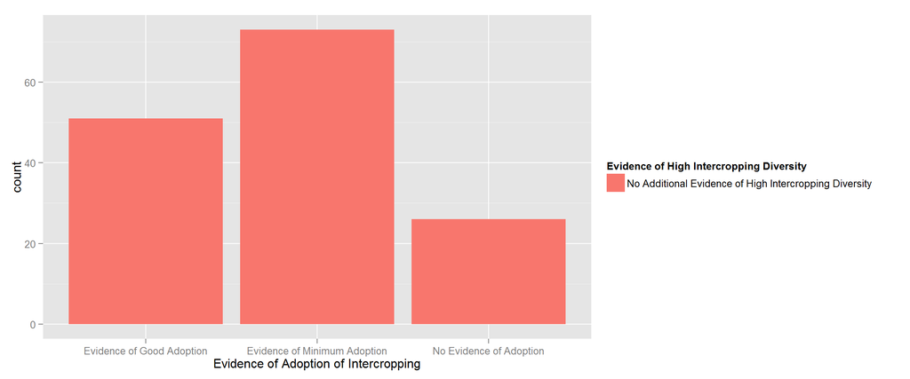

```
## [[1]]
## [[1]][[1]]
##      fill  y count x ndensity ncount  density PANEL group ymin ymax xmin
## 1 #F8766D 51    51 1        1      1 1.111111     1     1    0   51 0.55
## 2 #F8766D 73    73 2        1      1 1.111111     1     2    0   73 1.55
## 3 #F8766D 26    26 3        1      1 1.111111     1     3    0   26 2.55
##   xmax
## 1 1.45
## 2 2.45
## 3 3.45
```

```r
ifelse(nrow(integapfinal)==0 | all(is.na(integapfinal$evaluation)),"No Intercropping Data In Dataset, or all values <NA>",print(
ggplot(data=integapfinal, aes(integapfinal$evaluation)) + geom_bar(aes(fill=evaluationplus)) + xlab("Evidence of Adoption of Intercropping") + labs(fill='Evidence of High Intercropping Diversity')))
```

### Cocoa Farm Shade Management

**Changelog: recoded all A* values to adapt answer options 888, 999**

```r
cocoavars5 <- grep("^S_FID$|^PM2$|^A1_.|^A3_.|^A5_.|^A7_.", names(cocoavisit), value=TRUE) #select only shad management variables
shadgap <- cocoavisit[cocoavars5] #data table for shad GAP
cocoavars5full <- grep("^A1_.|^A3_.|^A5_.|^A7_.", names(shadgap), value=TRUE) #select only countable score variables
shadgap[grep("^A1_.",cocoavars5,value=TRUE)] <- recode(unlist(shadgap[grep("^A1_.",cocoavars5,value=TRUE)]),"888=50;999=27") #recoding values
shadgap[grep("^A3_.",cocoavars5,value=TRUE)] <- recode(unlist(shadgap[grep("^A3_.",cocoavars5,value=TRUE)]),"888=50;999=27") #recoding values
shadgap[grep("^A5_.",cocoavars5,value=TRUE)] <- recode(unlist(shadgap[grep("^A5_.",cocoavars5,value=TRUE)]),"888=50;999=27") #recoding values
shadgap[grep("^A7_.",cocoavars5,value=TRUE)] <- recode(unlist(shadgap[grep("^A7_.",cocoavars5,value=TRUE)]),"888=50;999=27") #recoding values
shadgap$NAcount <- apply(shadgap[cocoavars5full],1,function(x) length(which(is.na(x))))
shadgap$NAcheck <- ifelse((apply(shadgap[grep("^A1_.|^A3_.",cocoavars5,value=TRUE)],1,function(x) length(which(is.na(x)))) ==
apply(shadgap[grep("^A5_.|^A7_.",cocoavars5,value=TRUE)],1,function(x) length(which(is.na(x))))),"1","NA") #checks that for every observation component the same number of trees have been checked
shadgap$score <- colMeans(matrix(sapply((sapply(rowSums(shadgap[cocoavars5full],na.rm=TRUE), function(x) x / c(1.2,1.3,1.4,1.5)) / (as.vector(sapply((apply(shadgap[grep("^A1_.|^A3_.|^A5_.|^A7_.",cocoavars5full,value=TRUE)],1,function(x) length(which(!is.na(x))))), function (x) rep.int(x,4))))), function (x) 10000 / (x^2)),nrow=4))  #scores per entry and category, ignoring NA and computing average shade trees per 1 hectare, averaging out pacing distance of enumerators from 1.2 to 1.5 paces per meter
shadgap$evaluation <- ifelse(is.na(shadgap$NAcheck),NA,ifelse(apply(shadgap["score"], 1, max) < 12,"No Evidence of Adoption","Evidence of Minimum Adoption")) #evaluation of all criteria together
shadgapfinal <- (shadgap[c("S_FID","NAcheck","score","evaluation")]) #filter only cases for cass only
colnames(shadgapfinal)[1] <- "C1"
write.table(shadgapfinal, "CocoaFarm_shadeManagement.txt", sep="\t")
print(head(shadgapfinal))
```

```
##        C1 NAcheck      score                   evaluation
## 1  333546       1 290.336616 Evidence of Minimum Adoption
## 2  903764       1   8.786252      No Evidence of Adoption
## 3 1739243       1   8.703529      No Evidence of Adoption
## 4 1846372       1 203.324100 Evidence of Minimum Adoption
## 5 2014877       1   7.801042      No Evidence of Adoption
## 6 2034433       1  33.464622 Evidence of Minimum Adoption
```

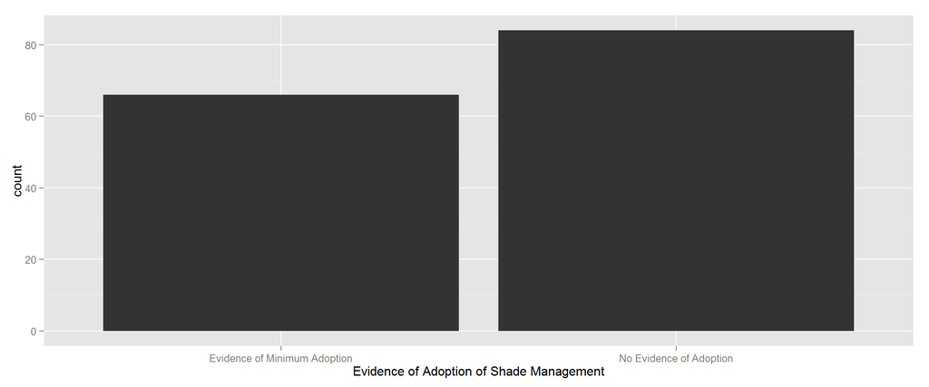

```
## [[1]]
## [[1]][[1]]
##    y count x ndensity ncount  density PANEL group ymin ymax xmin xmax
## 1 66    66 1        1      1 1.111111     1     1    0   66 0.55 1.45
## 2 84    84 2        1      1 1.111111     1     2    0   84 1.55 2.45
```

```r
ifelse(nrow(shadgapfinal)==0 | all(is.na(shadgapfinal$evaluation)),"No Shade Management Data In Dataset, or all values <NA>",print(
ggplot(data=shadgapfinal, aes(shadgapfinal$evaluation)) + geom_histogram() + xlab("Evidence of Adoption of Shade Management")))
```

## Cocoa Practices - Household Survey Rubrics

### Pest Management - Household Survey

**Changelog: recoding values for Q48 had to switch**

```r
hhpestvars1 <- grep("^C1$|^Q47SUM_.$|^Q48SUM_.|^Q21SUM_.|^Q38$", names(hhsurvey), value=TRUE) #select only shad management variables
hhpest <- hhsurvey[hhpestvars1] #data table for hhpest
hhpestvars1full <- grep("^Q47SUM_.$|^Q48SUM_.|^Q21SUM_.|^Q38$", names(hhpest), value=TRUE) #select only countable score variables
hhpest[grep("^Q47SUM_.",hhpestvars1,value=TRUE)] <- recode(unlist(hhpest[grep("^Q47SUM_.",hhpestvars1,value=TRUE)]),"1=1;7=1;9=1;2:6=0;8=0;else=NA") #recoding values
hhpest$Q47SUM_sum <- rowSums(hhpest[grep("^Q47SUM_.",hhpestvars1,value=TRUE)], na.rm=TRUE)
hhpest[grep("^Q48SUM_.",hhpestvars1,value=TRUE)] <- recode(unlist(hhpest[grep("^Q48SUM_.",hhpestvars1,value=TRUE)]),"1:4=1;5:7=0;else=NA") #recoding values; applying pesticides is not counted double since it appears in Q38 again
hhpest$Q48SUM_sum <- ifelse(rowSums(hhpest[grep("^Q48SUM_.",hhpestvars1,value=TRUE)], na.rm=TRUE) >= 1, 1,0)
hhpest[grep("^Q21SUM_.",hhpestvars1,value=TRUE)] <- recode(unlist(hhpest[grep("^Q21SUM_.",hhpestvars1,value=TRUE)]),"2=1;6=1;8=1;1=0;3:5=0;7=0;9=0;else=NA") #recoding values
hhpest$Q21SUM_sum <- ifelse(rowSums(hhpest[grep("^Q21SUM_.",hhpestvars1,value=TRUE)], na.rm=TRUE) >= 1, 1,0)
hhpest[grep("^Q38$",hhpestvars1,value=TRUE)] <- recode(unlist(hhpest[grep("^Q38$",hhpestvars1,value=TRUE)]),"1=1;2=0;else=NA") #recoding values
hhpest$NAcount <- apply(hhpest[hhpestvars1],1,function(x) length(which(is.na(x))))
hhpest$score <- hhpest$Q47SUM_sum - (hhpest$Q48SUM_sum + hhpest$Q21SUM_sum + hhpest$Q38)  #scores per entry and category, ignoring NA
hhpest$evaluation <- ifelse((hhpest$score > 0) & ((hhpest$Q48SUM_sum + hhpest$Q21SUM_sum + hhpest$Q38) == 0), "No Evidence of Adoption",
                                ifelse((hhpest$score > 0) & ((hhpest$Q48SUM_sum + hhpest$Q21SUM_sum + hhpest$Q38) > 0),"Evidence of Minimum Adoption",
                                       ifelse((hhpest$score < 0) & (hhpest$Q47SUM_sum > 0) & (hhpest$Q38 > 0),"Evidence of Excellent Adoption","Evidence of Good Adoption"))) #evaluation of all criteria together
hhpestfinal <- (hhpest[c("C1","Q38","Q21SUM_sum","Q47SUM_sum","Q48SUM_sum","NAcount","score","evaluation")]) #filter only cases for cass only
write.table(hhpestfinal, "HhSurvey_PestManagement.txt", sep="\t")
print(head(hhpestfinal))
```

```
##         C1 Q38 Q21SUM_sum Q47SUM_sum Q48SUM_sum NAcount score
## 1 33013380   1          0          2          1      25     0
## 2 33013379   1          0          1          1      27    -1
## 3 33013340   1          0          0          1      30    -2
## 4 33013391   1          0          2          1      21     0
## 5 33013354   1          0          0          1      30    -2
## 6 32011437   1          0          4          1      22     2
##                       evaluation
## 1      Evidence of Good Adoption
## 2 Evidence of Excellent Adoption
## 3      Evidence of Good Adoption
## 4      Evidence of Good Adoption
## 5      Evidence of Good Adoption
## 6   Evidence of Minimum Adoption
```

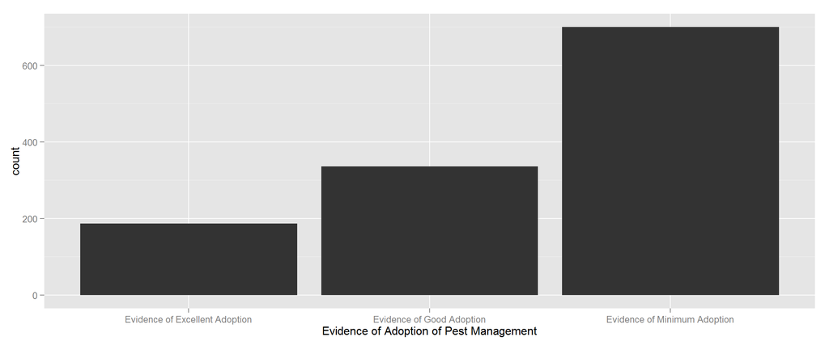

```
## [[1]]
## [[1]][[1]]
##     y count x ndensity ncount  density PANEL group ymin ymax xmin xmax
## 1 187   187 1        1      1 1.111111     1     1    0  187 0.55 1.45
## 2 336   336 2        1      1 1.111111     1     2    0  336 1.55 2.45
## 3 700   700 3        1      1 1.111111     1     3    0  700 2.55 3.45
```

```r
ifelse(nrow(hhpestfinal)==0 | all(is.na(hhpestfinal$evaluation)),"No Pest Management Data In Dataset, or all values <NA>",print(
ggplot(data=hhpestfinal, aes(hhpestfinal$evaluation)) + geom_histogram() + xlab("Evidence of Adoption of Pest Management")))
```

### Weed Management - Household Survey

```r
hhweedvars2 <- grep("^C1$|^Q28$|^Q27$", names(hhsurvey), value=TRUE) #select only shad management variables
hhweed <- hhsurvey[hhweedvars2] #data table for hhweed
hhweedvars2full <- grep("^Q28$|^Q27$", names(hhweed), value=TRUE) #select only countable score variables
hhweed[grep("^Q28$",hhweedvars2,value=TRUE)] <- recode(unlist(hhweed[grep("^Q28$",hhweedvars2,value=TRUE)]),"1=2;2=1;3=0;else=NA") #recoding values
hhweed[grep("^Q27$",hhweedvars2,value=TRUE)] <- recode(unlist(hhweed[grep("^Q27$",hhweedvars2,value=TRUE)]),"1=0;2:7=1;else=NA") #recoding values
hhweed$NAcount <- apply(hhweed[hhweedvars2],1,function(x) length(which(is.na(x))))
hhweed$score <- hhweed$Q28 - hhweed$Q27  #scores per entry and category, ignoring NA
hhweed$evaluation <- ifelse((hhweed$score > 0) & (hhweed$Q27 == 0), "No Evidence of Adoption",
                                ifelse((hhweed$score > 0) & (hhweed$Q27 > 0),"Evidence of Minimum Adoption","Evidence of Good/Excellent Adoption")) #evaluation of all criteria together
hhweedfinal <- (hhweed[c("C1","NAcount","score","evaluation")]) #filter only cases for cass only
write.table(hhweedfinal, "HhSurvey_weedManagement.txt", sep="\t")
print(head(hhweedfinal))
```

```
##         C1 NAcount score                          evaluation
## 1 33013380       0     0 Evidence of Good/Excellent Adoption
## 2 33013379       0     0 Evidence of Good/Excellent Adoption
## 3 33013340       0    -1 Evidence of Good/Excellent Adoption
## 4 33013391       0    -1 Evidence of Good/Excellent Adoption
## 5 33013354       0     0 Evidence of Good/Excellent Adoption
## 6 32011437       0     0 Evidence of Good/Excellent Adoption
```

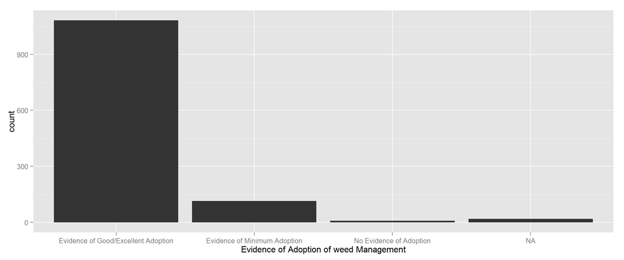

```
## [[1]]
## [[1]][[1]]
##      y count x ndensity ncount  density PANEL group ymin ymax xmin xmax
## 1 1082  1082 1        1      1 1.111111     1     1    0 1082 0.55 1.45
## 2  114   114 2        1      1 1.111111     1     2    0  114 1.55 2.45
## 3    8     8 3        1      1 1.111111     1     3    0    8 2.55 3.45
## 4   19    19 4        1      1 1.111111     1     4    0   19 3.55 4.45
```

```r
ifelse(nrow(hhweedfinal)==0 | all(is.na(hhweedfinal$evaluation)),"No weed Management Data In Dataset, or all values <NA>",print(
ggplot(data=hhweedfinal, aes(hhweedfinal$evaluation)) + geom_histogram() + xlab("Evidence of Adoption of weed Management")))
```

### Pruning Management - Household Survey

```r
hhprunvars3 <- grep("^C1$|^Q24$|^Q25$", names(hhsurvey), value=TRUE) #select only shad management variables
hhprun <- hhsurvey[hhprunvars3] #data table for hhprun
hhprunvars3full <- grep("^Q24$|^Q25$", names(hhprun), value=TRUE) #select only countable score variables
hhprun[grep("^Q24$",hhprunvars3,value=TRUE)] <- recode(unlist(hhprun[grep("^Q24$",hhprunvars3,value=TRUE)]),"1=2;2=1;3=0;else=NA") #recoding values
hhprun[grep("^Q25$",hhprunvars3,value=TRUE)] <- recode(unlist(hhprun[grep("^Q25$",hhprunvars3,value=TRUE)]),"1=0;2:7=1;else=NA") #recoding values
hhprun$NAcount <- apply(hhprun[hhprunvars3],1,function(x) length(which(is.na(x))))
hhprun$score <- hhprun$Q24 - hhprun$Q25  #scores per entry and category, ignoring NA
hhprun$evaluation <- ifelse((hhprun$score > 0) & (hhprun$Q25 == 0), "No Evidence of Adoption",
                                ifelse((hhprun$score > 0) & (hhprun$Q25 > 0),"Evidence of Minimum Adoption","Evidence of Good/Excellent Adoption")) #evaluation of all criteria together
hhprunfinal <- (hhprun[c("C1","NAcount","score","evaluation")]) #filter only cases for cass only
write.table(hhprunfinal, "HhSurvey_prunManagement.txt", sep="\t")
print(head(hhprunfinal))
```

```
##         C1 NAcount score                   evaluation
## 1 33013380       0     1 Evidence of Minimum Adoption
## 2 33013379       0     1 Evidence of Minimum Adoption
## 3 33013340       0     2      No Evidence of Adoption
## 4 33013391       0     1 Evidence of Minimum Adoption
## 5 33013354       1    NA                         <NA>
## 6 32011437       0     1 Evidence of Minimum Adoption
```

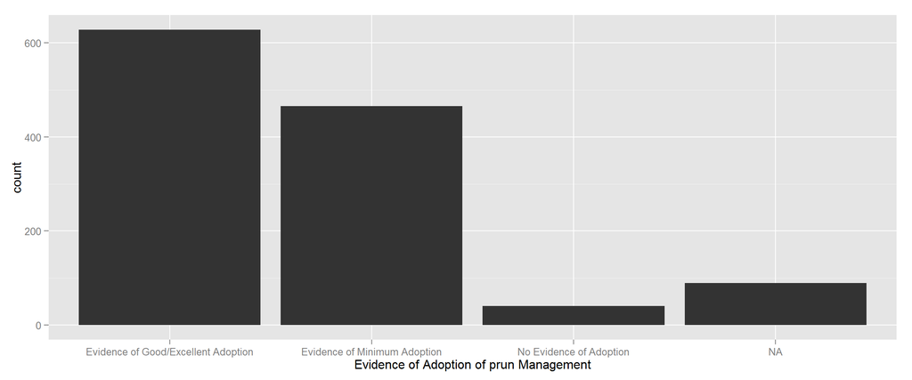

```
## [[1]]
## [[1]][[1]]
##     y count x ndensity ncount  density PANEL group ymin ymax xmin xmax
## 1 628   628 1        1      1 1.111111     1     1    0  628 0.55 1.45
## 2 466   466 2        1      1 1.111111     1     2    0  466 1.55 2.45
## 3  40    40 3        1      1 1.111111     1     3    0   40 2.55 3.45
## 4  89    89 4        1      1 1.111111     1     4    0   89 3.55 4.45
```

```r
ifelse(nrow(hhprunfinal)==0 | all(is.na(hhprunfinal$evaluation)),"No prun Management Data In Dataset, or all values <NA>",print(
ggplot(data=hhprunfinal, aes(hhprunfinal$evaluation)) + geom_histogram() + xlab("Evidence of Adoption of prun Management")))
```

### Shade Management - Household Survey

**Changelog: please observe that I have no means to track which case is from which country—right now, I adapted the area unit for in line 255 || completely removed Q29 since it has been removed from survey (was redundant anyhow and only a double check) || had to change recoding of Q30 and S1_.*B to account for 888 and 999 options**

```r
hhshadvars4 <- grep("^C1$|^S1_.*B$|^Q30$", names(hhsurvey), value=TRUE) #select only shad management variables
hhshad <- hhsurvey[hhshadvars4] #data table for hhshad
hhshadvars4full <- grep("^S1_.*B$|^Q30$", names(hhshad), value=TRUE) #select only countable score variables
hhshad[grep("^S1_.*B$",hhshadvars4,value=TRUE)] <- recode(unlist(hhshad[grep("^S1_.*B$",hhshadvars4,value=TRUE)]),"888=NA;999=NA") #recoding values
hhshad$Q30[hhshad$Q30==888] <- NA
hhshad$Q30[hhshad$Q30==999] <- NA
hhshad$S1_sum <- rowSums(hhshad[grep("^S1_.*B$",hhshadvars4,value=TRUE)],na.rm=TRUE) #recoding values
hhshad$NAcount <- apply(hhshad[hhshadvars4],1,function(x) length(which(is.na(x))))
hhshad$score <- ifelse(hhshad$S1_sum == 0,NA,hhshad$Q30 / (hhshad$S1_sum * 2.47105))  #scores per entry and category, ignoring NA
hhshad$evaluation <- ifelse((hhshad$score <= 12), "No Evidence of Adoption","Evidence of Minimum Adoption") #evaluation of all criteria together
hhshadfinal <- (hhshad[c("C1","NAcount","score","evaluation")]) #filter only cases for cass only
write.table(hhshadfinal, "HhSurvey_shadManagement.txt", sep="\t")
print(head(hhshadfinal))
```

```
##         C1 NAcount     score              evaluation
## 1 33013380       0 1.5175735 No Evidence of Adoption
## 2 33013379       0 1.0406218 No Evidence of Adoption
## 3 33013340       0 0.9249972 No Evidence of Adoption
## 4 33013391       0 2.4281176 No Evidence of Adoption
## 5 33013354       0 4.0468627 No Evidence of Adoption
## 6 32011437       0 2.0234313 No Evidence of Adoption
```

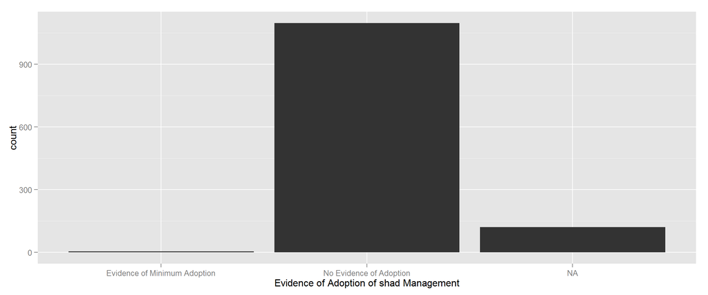

```
## [[1]]
## [[1]][[1]]
##      y count x ndensity ncount  density PANEL group ymin ymax xmin xmax
## 1    5     5 1        1      1 1.111111     1     1    0    5 0.55 1.45
## 2 1097  1097 2        1      1 1.111111     1     2    0 1097 1.55 2.45
## 3  121   121 3        1      1 1.111111     1     3    0  121 2.55 3.45
```

```r
ifelse(nrow(hhshadfinal)==0 | all(is.na(hhshadfinal$evaluation)),"No shad Management Data In Dataset, or all values <NA>",print(
ggplot(data=hhshadfinal, aes(hhshadfinal$evaluation)) + geom_histogram() + xlab("Evidence of Adoption of shad Management")))
```

### Farm Rehabilitation - Household Survey

```r
hhrehavars5 <- grep("^C1$|^Q6$|^Q7$|^Q2$", names(hhsurvey), value=TRUE) #select only reha management variables
hhreha <- hhsurvey[hhrehavars5] #data table for hhreha
hhrehavars5full <- grep("^Q6$|^Q7$|^Q2$", names(hhreha), value=TRUE) #select only countable score variables
hhreha[grep("^Q2$",hhrehavars5,value=TRUE)] <- recode(unlist(hhreha[grep("^Q2$",hhrehavars5,value=TRUE)]),"1=1;2:5=0;else=NA") #recoding values
hhreha[grep("^Q6$",hhrehavars5,value=TRUE)] <- recode(unlist(hhreha[grep("^Q6$",hhrehavars5,value=TRUE)]),"1=1;2=0;else=NA") #recoding values
hhreha[grep("^Q7$",hhrehavars5,value=TRUE)] <- recode(unlist(hhreha[grep("^Q7$",hhrehavars5,value=TRUE)]),"1=1;2=0;else=NA") #recoding values
hhreha$NAcount <- apply(hhreha[hhrehavars5],1,function(x) length(which(is.na(x))))
hhreha$evaluation <- ifelse((hhreha$Q6 == 0) & (hhreha$Q2 == 0), "No Evidence of Adoption","Evidence of Minimum Adoption") #evaluation of all criteria together
hhreha$evaluationplus <- ifelse((hhreha$Q7 == 0) & (hhreha$Q6 == 1), "Farmer is Likely Creating New Areas or Pockets With Cocoa","Famer is Likely Replanting Old Fields") #evaluation of all criteria together
hhrehafinal <- (hhreha[c("C1","NAcount","evaluation","evaluationplus")]) #filter only cases for cass only
write.table(hhrehafinal, "HhSurvey_rehaManagement.txt", sep="\t")
print(head(hhrehafinal))
```

```
##         C1 NAcount                   evaluation
## 1 33013380       1      No Evidence of Adoption
## 2 33013379       0 Evidence of Minimum Adoption
## 3 33013340       1      No Evidence of Adoption
## 4 33013391       0 Evidence of Minimum Adoption
## 5 33013354       0 Evidence of Minimum Adoption
## 6 32011437       0 Evidence of Minimum Adoption
##                                              evaluationplus
## 1                     Famer is Likely Replanting Old Fields
## 2                     Famer is Likely Replanting Old Fields
## 3                     Famer is Likely Replanting Old Fields
## 4 Farmer is Likely Creating New Areas or Pockets With Cocoa
## 5                     Famer is Likely Replanting Old Fields
## 6 Farmer is Likely Creating New Areas or Pockets With Cocoa
```

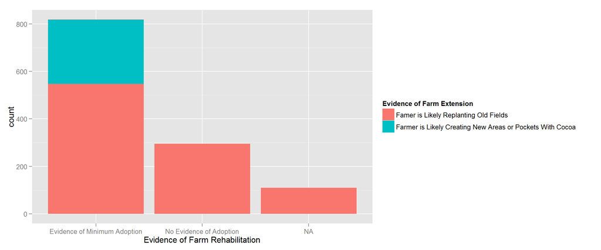

```
## [[1]]
## [[1]][[1]]
##      fill   y count x ndensity ncount  density PANEL group ymin ymax xmin
## 1 #F8766D 547   547 1        1      1 1.111111     1     1    0  547 0.55
## 2 #00BFC4 817   270 1        1      1 1.111111     1     4  547  817 0.55
## 3  grey50 818     1 1        1      1 1.111111     1     5  817  818 0.55
## 4 #F8766D 295   295 2        1      1 1.111111     1     2    0  295 1.55
## 5 #F8766D 110   110 3        1      1 1.111111     1     3    0  110 2.55
##   xmax
## 1 1.45
## 2 1.45
## 3 1.45
## 4 2.45
## 5 3.45
```

```r
ifelse(nrow(hhrehafinal)==0 | all(is.na(hhrehafinal$evaluation)),"No Rehabilitation Data In Dataset, or all values <NA>",print(
ggplot(data=hhrehafinal, aes(hhrehafinal$evaluation)) + geom_bar(aes(fill=evaluationplus)) + xlab("Evidence of Farm Rehabilitation") + labs(fill='Evidence of Farm Extension')))
```

## Food Crop Farm Visit Rubrics

**Changelog: replaced all ^INTERVIEWER$ variables by ^S1$ for the ID (will still be renamed C1 to fit the other surveys) | M items changed from M2-9 to M1-9; M10 is out and M17 remains | the variable Ma transformed to MA_1A | modified filtering for cases to subset() in line 315 and corresponding**

### Cassava Good Agricultural Practices

```r
foodvars1 <- grep("K1$|K2$|S1|MA_1A|^[M][1-9]_.|M17$", names(foodvisit), value=TRUE) #select only variables for cass GAPs
cassgap <- foodvisit[foodvars1] #data table for cassava GAP
foodvars1full <- names(cassgap[grep("^[M][1-9]_.|M17$",names(cassgap),value=TRUE)]) #variables of farm visit with multiple observation points
foodvars1short <- names(cassgap[grep("^[M][1-9]_1|M17$",names(cassgap),value=TRUE)]) #variables of farm visit with one observation point
NAlist1 <-  names(cassgap[grep("^M4_.$",names(cassgap),value=TRUE)]) #list of all variables which are allowed to be NA
cassgap[grep("M1_.",foodvars1,value=TRUE)] <- recode(unlist(cassgap[grep("M1_.",foodvars1,value=TRUE)]),"1=1;2=0;3=NA;else=NA") #recoding values
cassgap[grep("M2_.",foodvars1,value=TRUE)] <- recode(unlist(cassgap[grep("M2_.",foodvars1,value=TRUE)]),"3=1;c('1','2','4','5')='0';else=NA") #recoding values
cassgap[grep("M3_.",foodvars1,value=TRUE)] <- recode(unlist(cassgap[grep("M3_.",foodvars1,value=TRUE)]),"4=1;c('1','2','3','5')='0';else=NA") #recoding values
cassgap[grep("M4_.",foodvars1,value=TRUE)] <- recode(unlist(cassgap[grep("M4_.",foodvars1,value=TRUE)]),"1=1;2=0;3=NA;else=NA") #recoding values
cassgap[grep("M5_.",foodvars1,value=TRUE)] <- recode(unlist(cassgap[grep("M5_.",foodvars1,value=TRUE)]),"1=0;2=1;3=NA;else=NA") #recoding values
cassgap[grep("M6_.",foodvars1,value=TRUE)] <- recode(unlist(cassgap[grep("M6_.",foodvars1,value=TRUE)]),"1=0;2=1;3=NA;else=NA") #recoding values
cassgap[grep("M7_.",foodvars1,value=TRUE)] <- recode(unlist(cassgap[grep("M7_.",foodvars1,value=TRUE)]),"1=0;2=1;3=NA;else=NA") #recoding values
cassgap[grep("M8_.",foodvars1,value=TRUE)] <- recode(unlist(cassgap[grep("M8_.",foodvars1,value=TRUE)]),"1=1;2=0;3=NA;else=NA") #recoding values
cassgap[grep("M9_.",foodvars1,value=TRUE)] <- recode(unlist(cassgap[grep("M9_.",foodvars1,value=TRUE)]),"1=1;2=0;3=NA;else=NA") #recoding values
cassgap[grep("M17",foodvars1,value=TRUE)] <- recode(unlist(cassgap[grep("M17",foodvars1,value=TRUE)]),"1=1;2=0;3=NA;else=NA") #recoding values
cassgap$NAcount <- apply(cassgap[foodvars1full],1,function(x) length(which(is.na(x))))
NAcheck1 <- ifelse(cassgap$MA_1A=='1',
apply(cassgap[foodvars1short],1, function(x) names(which(is.na(x)))),
apply(cassgap[foodvars1full],1, function(x) names(which(is.na(x))))) #check all cases for which NAs occur depending on MA_1A
NAcheckresult1 <- sapply(NAcheck1,function(x) x %in% NAlist1) #check that only permissible NAs occur in rows
NAchecklist1 <- which(sapply(NAcheckresult1,function(x) all(x=="TRUE"))=="FALSE") #check which element has not permitted NAs
cassgap$score <- ifelse(cassgap$MA_1A=='1',rowSums(cassgap[foodvars1short],na.rm=TRUE),rowSums(cassgap[foodvars1full],na.rm=TRUE)) #will ignore all NA values
cassgap$score[NAchecklist1] <- NA #replace all cases with unallowed NAs with Na
cassgap$perc <- ifelse((length(foodvars1full)-cassgap$NAcount)==0,NA,round(cassgap$score/(length(foodvars1full)-cassgap$NAcount)*100,digits=0)) #will remove NA casewise
cassgap$scoreNArm <- ifelse(cassgap$MA_1A=='1',rowSums(cassgap[foodvars1short],na.rm=TRUE),rowSums(cassgap[foodvars1full],na.rm=TRUE)) #second score which keeps all cases with NA removed
cassgap$percNArm <- ifelse((length(foodvars1full)-cassgap$NAcount)==0,NA,round(cassgap$scoreNArm/(length(foodvars1full)-cassgap$NAcount)*100,digits=0)) #will ignore NA values
cassgap$evaluationNArm <- recode(cassgap$percNArm,"0:30='a) No Evidence of Adoption';31:50='b) Evidence of Minimum Adoption';51:70='c) Evidence of Good Adoption';71:100='d) Evidence of Excellent Adoption'")
cassgap$evaluation <- recode(cassgap$perc,"0:30='a) No Evidence of Adoption';31:50='b) Evidence of Minimum Adoption';51:70='c) Evidence of Good Adoption';71:100='d) Evidence of Excellent Adoption'")
cassgapfinal <- subset(cassgap, ((K1 == 1) | (K2 == 1))) #filter only cases for cass only
colnames(cassgapfinal)[3] <- "C1"
cassgapfinal2 <- cassgapfinal[c("C1","NAcount","score","perc","scoreNArm","percNArm","evaluationNArm","evaluation")]
write.table(cassgapfinal2, "FoodCropFarm_cassavaManagement.txt", sep="\t")
print(head(cassgapfinal))
```

```
##    K1 K2       C1 MA_1A M1_1 M2_1 M3_1 M4_1 M5_1 M6_1 M7_1 M8_1 M9_1 M1_2
## 7   1 NA 38049552     1    1    1   NA    1    0    1    0    0    1   NA
## 12 NA  1 34018451     1    1    0   NA    1    1    1    0    1    0   NA
## 13  1 NA 38049642     1    1    0   NA    1    0    1    1    0    1   NA
## 17  1 NA 38055275     1    1    0   NA    1    1    1    1    0    1   NA
## 18 NA  1 34025772     1    1    0   NA    1    1    1    0    1    0   NA
## 20 NA  1 34025548     1    1    0   NA    1    1    1    0    1    0   NA
##    M2_2 M3_2 M4_2 M5_2 M6_2 M7_2 M8_2 M9_2 M1_3 M2_3 M3_3 M4_3 M5_3 M6_3
## 7    NA   NA   NA   NA   NA   NA   NA   NA   NA   NA   NA   NA   NA   NA
## 12   NA   NA   NA   NA   NA   NA   NA   NA   NA   NA   NA   NA   NA   NA
## 13   NA   NA   NA   NA   NA   NA   NA   NA   NA   NA   NA   NA   NA   NA
## 17   NA   NA   NA   NA   NA   NA   NA   NA   NA   NA   NA   NA   NA   NA
## 18   NA   NA   NA   NA   NA   NA   NA   NA   NA   NA   NA   NA   NA   NA
## 20   NA   NA   NA   NA   NA   NA   NA   NA   NA   NA   NA   NA   NA   NA
##    M7_3 M8_3 M9_3 M17 NAcount score perc scoreNArm percNArm
## 7    NA   NA   NA   1      19    NA   NA         6       67
## 12   NA   NA   NA   1      19    NA   NA         6       67
## 13   NA   NA   NA   1      19    NA   NA         6       67
## 17   NA   NA   NA   0      19    NA   NA         6       67
## 18   NA   NA   NA   0      19    NA   NA         5       56
## 20   NA   NA   NA   0      19    NA   NA         5       56
##                  evaluationNArm evaluation
## 7  c) Evidence of Good Adoption       <NA>
## 12 c) Evidence of Good Adoption       <NA>
## 13 c) Evidence of Good Adoption       <NA>
## 17 c) Evidence of Good Adoption       <NA>
## 18 c) Evidence of Good Adoption       <NA>
## 20 c) Evidence of Good Adoption       <NA>
```

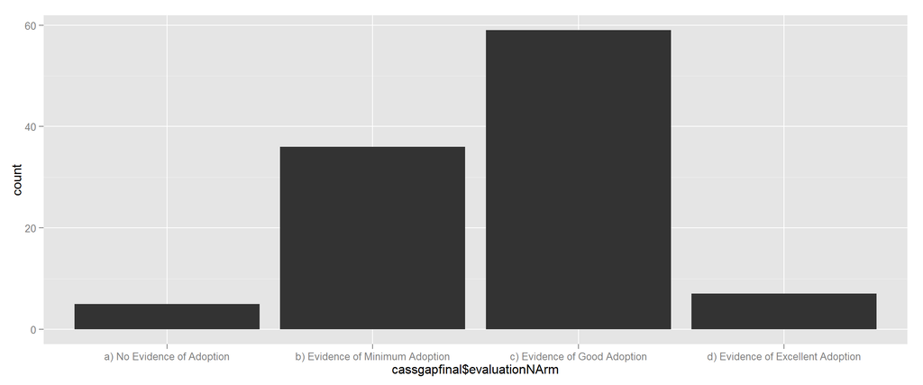

```
## [[1]]
## [[1]][[1]]
##    y count x ndensity ncount  density PANEL group ymin ymax xmin xmax
## 1  5     5 1        1      1 1.111111     1     1    0    5 0.55 1.45
## 2 36    36 2        1      1 1.111111     1     2    0   36 1.55 2.45
## 3 59    59 3        1      1 1.111111     1     3    0   59 2.55 3.45
## 4  7     7 4        1      1 1.111111     1     4    0    7 3.55 4.45
```

```r
ifelse(nrow(cassgapfinal)==0 | all(is.na(cassgapfinal$evaluationNArm)),"No cassava Data In Dataset, or all values <NA>",print(
ggplot(data=cassgapfinal, aes(cassgapfinal$evaluationNArm)) + geom_histogram() )) #ignore NA
```

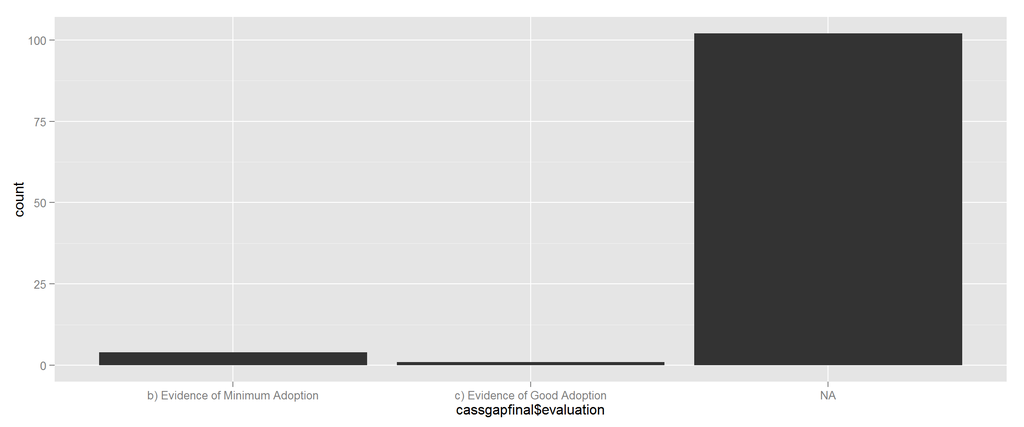

```
## [[1]]
## [[1]][[1]]
##     y count x ndensity ncount  density PANEL group ymin ymax xmin xmax
## 1   4     4 1        1      1 1.111111     1     1    0    4 0.55 1.45
## 2   1     1 2        1      1 1.111111     1     2    0    1 1.55 2.45
## 3 102   102 3        1      1 1.111111     1     3    0  102 2.55 3.45
```

```r
ifelse(nrow(cassgapfinal)==0 | all(is.na(cassgapfinal$evaluation)),"No cassava Data In Dataset, or all values <NA>",print(
ggplot(data=cassgapfinal, aes(cassgapfinal$evaluation)) + geom_histogram() )) #remove NA casewise
```

### Plantain Good Agricultural Practices

```r
foodvars2 <- grep("K1$|K2$|S1|MA_1A|^[M][1-9]_.|11_.|12_.|M17$", names(foodvisit), value=TRUE) #select only variables for plan GAPs
plangap <- foodvisit[foodvars2] #data table for planava GAP
foodvars2full <- names(plangap[grep("^[M][1-9]_.|11_.|12_.|M17$",names(plangap),value=TRUE)]) #variables of farm visit with multiple observation points
foodvars2short <- names(plangap[grep("^[M][1-9]_1|11_1|12_1|M17$",names(plangap),value=TRUE)]) #variables of farm visit with one observation point
NAlist2 <-  names(plangap[grep("^M4_.|11_.|12_.$",names(plangap),value=TRUE)]) #list of all variables which are allowed to be NA
plangap[grep("M1_.",foodvars2,value=TRUE)] <- recode(unlist(plangap[grep("M1_.",foodvars2,value=TRUE)]),"1=1;2=0;3=NA;else=NA") #recoding values
plangap[grep("M2_.",foodvars2,value=TRUE)] <- recode(unlist(plangap[grep("M2_.",foodvars2,value=TRUE)]),"3=1;c('1','2','4','5')='0';else=NA") #recoding values
plangap[grep("M3_.",foodvars2,value=TRUE)] <- recode(unlist(plangap[grep("M3_.",foodvars2,value=TRUE)]),"4=1;c('1','2','3','5')='0';else=NA") #recoding values
plangap[grep("M4_.",foodvars2,value=TRUE)] <- recode(unlist(plangap[grep("M4_.",foodvars2,value=TRUE)]),"1=1;2=0;3=NA;else=NA") #recoding values
plangap[grep("M5_.",foodvars2,value=TRUE)] <- recode(unlist(plangap[grep("M5_.",foodvars2,value=TRUE)]),"1=0;2=1;3=NA;else=NA") #recoding values
plangap[grep("M6_.",foodvars2,value=TRUE)] <- recode(unlist(plangap[grep("M6_.",foodvars2,value=TRUE)]),"1=0;2=1;3=NA;else=NA") #recoding values
plangap[grep("M7_.",foodvars2,value=TRUE)] <- recode(unlist(plangap[grep("M7_.",foodvars2,value=TRUE)]),"1=0;2=1;3=NA;else=NA") #recoding values
plangap[grep("M8_.",foodvars2,value=TRUE)] <- recode(unlist(plangap[grep("M8_.",foodvars2,value=TRUE)]),"1=1;2=0;3=NA;else=NA") #recoding values
plangap[grep("M9_.",foodvars2,value=TRUE)] <- recode(unlist(plangap[grep("M9_.",foodvars2,value=TRUE)]),"1=1;2=0;3=NA;else=NA") #recoding values
plangap[grep("M11_.",foodvars2,value=TRUE)] <- recode(unlist(plangap[grep("M11_.",foodvars2,value=TRUE)]),"1=1;2=0;3=NA;else=NA") #recoding values
plangap[grep("M12_.",foodvars2,value=TRUE)] <- recode(unlist(plangap[grep("M12_.",foodvars2,value=TRUE)]),"1=1;2=0;3=NA;else=NA") #recoding values
plangap[grep("M17",foodvars2,value=TRUE)] <- recode(unlist(plangap[grep("M17",foodvars2,value=TRUE)]),"1=1;2=0;3=NA;else=NA") #recoding values
NAcheck2 <- ifelse(plangap$MA_1A=='1',
apply(plangap[foodvars2short],1, function(x) names(which(is.na(x)))),
apply(plangap[foodvars2full],1, function(x) names(which(is.na(x))))) #check all cases for which NAs occur depending on MA_1A
NAcheckresult2 <- sapply(NAcheck2,function(x) x %in% NAlist2) #check that only permissible NAs occur in rows
NAchecklist2 <- which(sapply(NAcheckresult2,function(x) all(x=="TRUE"))=="FALSE") #check which element has not permitted NAs
plangap$NAcount <- apply(plangap[foodvars2full],1,function(x) length(which(is.na(x))))
plangap$score <- ifelse(plangap$MA_1A=='1',rowSums(plangap[foodvars2short],na.rm=TRUE),rowSums(plangap[foodvars2full],na.rm=TRUE)) #will ignore all NA values
plangap$score[NAchecklist2] <- NA #replace all cases with unallowed NAs with Na
plangap$perc <- ifelse((length(foodvars2full)-plangap$NAcount)==0,NA,round(plangap$score/(length(foodvars2full)-plangap$NAcount)*100,digits=0)) #will remove NA casewise
plangap$scoreNArm <- ifelse(plangap$MA_1A=='1',rowSums(plangap[foodvars2short],na.rm=TRUE),rowSums(plangap[foodvars2full],na.rm=TRUE)) #second score which keeps all cases with NA removed
plangap$percNArm <- ifelse((length(foodvars2full)-plangap$NAcount)==0,NA,round(plangap$scoreNArm/(length(foodvars2full)-plangap$NAcount)*100,digits=0)) #will ignore NA values
plangap$evaluationNArm <- recode(plangap$percNArm,"0:30='a) No Evidence of Adoption';31:50='b) Evidence of Minimum Adoption';51:70='c) Evidence of Good Adoption';71:100='d) Evidence of Excellent Adoption'")
plangap$evaluation <- recode(plangap$perc,"0:30='a) No Evidence of Adoption';31:50='b) Evidence of Minimum Adoption';51:70='c) Evidence of Good Adoption';71:100='d) Evidence of Excellent Adoption'")
plangapfinal <- subset(plangap, ((K1 == 2) | (K2 == 2))) #filter only cases for plan only
colnames(plangapfinal)[3] <- "C1"
plangapfinal2 <- plangapfinal[c("C1","NAcount","score","perc","scoreNArm","percNArm","evaluationNArm","evaluation")]
write.table(plangapfinal2, "FoodCropFarm_plantainManagement.txt", sep="\t")
print(head(plangapfinal))
```

```
##   K1 K2       C1 MA_1A M1_1 M2_1 M3_1 M4_1 M5_1 M6_1 M7_1 M8_1 M9_1 M11_1
## 1  2 NA 32007711     1    1    1   NA    1    1    1    0    0    0     0
## 2  2 NA 32010012     1    1    0   NA    1    0    0    0    1    0     0
## 3 NA  2 34033028     1    1    0   NA    1    1    1    1    1    0     0
## 4  2 NA 32007513     1    1    0   NA    1    1    1    1    1    0     1
## 5  2 NA 32011127     1    1    0   NA    1    0    1    0    0    1     0
## 6 NA  2 34019598     1    1    0   NA    1    1    1    0    0    1     1
##   M12_1 M1_2 M2_2 M3_2 M4_2 M5_2 M6_2 M7_2 M8_2 M9_2 M11_2 M12_2 M1_3 M2_3
## 1     0   NA   NA   NA   NA   NA   NA   NA   NA   NA    NA    NA   NA   NA
## 2     0   NA   NA   NA   NA   NA   NA   NA   NA   NA    NA    NA   NA   NA
## 3     0   NA   NA   NA   NA   NA   NA   NA   NA   NA    NA    NA   NA   NA
## 4     0   NA   NA   NA   NA   NA   NA   NA   NA   NA    NA    NA   NA   NA
## 5     0   NA   NA   NA   NA   NA   NA   NA   NA   NA    NA    NA   NA   NA
## 6     0   NA   NA   NA   NA   NA   NA   NA   NA   NA    NA    NA   NA   NA
##   M3_3 M4_3 M5_3 M6_3 M7_3 M8_3 M9_3 M11_3 M12_3 M17 NAcount score perc
## 1   NA   NA   NA   NA   NA   NA   NA    NA    NA   1      23    NA   NA
## 2   NA   NA   NA   NA   NA   NA   NA    NA    NA   1      23    NA   NA
## 3   NA   NA   NA   NA   NA   NA   NA    NA    NA   1      23    NA   NA
## 4   NA   NA   NA   NA   NA   NA   NA    NA    NA   1      23    NA   NA
## 5   NA   NA   NA   NA   NA   NA   NA    NA    NA   1      23    NA   NA
## 6   NA   NA   NA   NA   NA   NA   NA    NA    NA   1      23    NA   NA
##   scoreNArm percNArm                    evaluationNArm evaluation
## 1         6       55      c) Evidence of Good Adoption       <NA>
## 2         4       36   b) Evidence of Minimum Adoption       <NA>
## 3         7       64      c) Evidence of Good Adoption       <NA>
## 4         8       73 d) Evidence of Excellent Adoption       <NA>
## 5         5       45   b) Evidence of Minimum Adoption       <NA>
## 6         7       64      c) Evidence of Good Adoption       <NA>
```

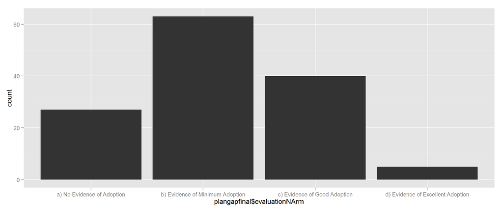

```
## [[1]]
## [[1]][[1]]
##    y count x ndensity ncount  density PANEL group ymin ymax xmin xmax
## 1 27    27 1        1      1 1.111111     1     1    0   27 0.55 1.45
## 2 63    63 2        1      1 1.111111     1     2    0   63 1.55 2.45
## 3 40    40 3        1      1 1.111111     1     3    0   40 2.55 3.45
## 4  5     5 4        1      1 1.111111     1     4    0    5 3.55 4.45
```

```r
ifelse(nrow(plangapfinal)==0 | all(is.na(plangapfinal$evaluationNArm)),"No plantain Data In Dataset, or all values <NA>",print(
ggplot(data=plangapfinal, aes(plangapfinal$evaluationNArm)) + geom_histogram() )) #ignore NA
```

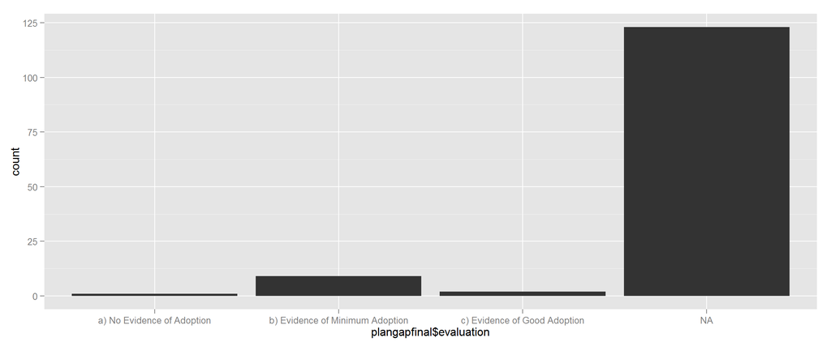

```
## [[1]]
## [[1]][[1]]
##     y count x ndensity ncount  density PANEL group ymin ymax xmin xmax
## 1   1     1 1        1      1 1.111111     1     1    0    1 0.55 1.45
## 2   9     9 2        1      1 1.111111     1     2    0    9 1.55 2.45
## 3   2     2 3        1      1 1.111111     1     3    0    2 2.55 3.45
## 4 123   123 4        1      1 1.111111     1     4    0  123 3.55 4.45
```

```r
ifelse(nrow(plangapfinal)==0 | all(is.na(plangapfinal$evaluation)),"No plantain Data In Dataset, or all values <NA>",print(
ggplot(data=plangapfinal, aes(plangapfinal$evaluation)) + geom_histogram() )) #remove NA casewise
```

### Vegetable Good Agricultural Practices

```r
foodvars3 <- grep("K1$|S1|MA_1A|^[M][1-9]_.|13_.|14_.|15_.|M17$", names(foodvisit), value=TRUE) #select only variables for vege GAPs
vegegap <- foodvisit[foodvars3] #data table for vegeava GAP
foodvars3full <- names(vegegap[grep("^[M][1-9]_.|13_.|14_.|15_.|M17$",names(vegegap),value=TRUE)]) #variables of farm visit with multiple observation points
foodvars3short <- names(vegegap[grep("^[M][1-9]_1|13_1|14_1|15_1|M17$",names(vegegap),value=TRUE)]) #variables of farm visit with one observation point
NAlist3 <-  names(vegegap[grep("^M4_.|11_.|12_.$",names(vegegap),value=TRUE)]) #list of all variables which are allowed to be NA
vegegap[grep("M1_.",foodvars3,value=TRUE)] <- recode(unlist(vegegap[grep("M1_.",foodvars3,value=TRUE)]),"1=1;2=0;3=NA;else=NA") #recoding values
vegegap[grep("M2_.",foodvars3,value=TRUE)] <- recode(unlist(vegegap[grep("M2_.",foodvars3,value=TRUE)]),"3=1;c('1','2','4','5')='0';else=NA") #recoding values
vegegap[grep("M3_.",foodvars3,value=TRUE)] <- recode(unlist(vegegap[grep("M3_.",foodvars3,value=TRUE)]),"4=1;c('1','2','3','5')='0';else=NA") #recoding values
vegegap[grep("M4_.",foodvars3,value=TRUE)] <- recode(unlist(vegegap[grep("M4_.",foodvars3,value=TRUE)]),"1=1;2=0;3=NA;else=NA") #recoding values
vegegap[grep("M5_.",foodvars3,value=TRUE)] <- recode(unlist(vegegap[grep("M5_.",foodvars3,value=TRUE)]),"1=0;2=1;3=NA;else=NA") #recoding values
vegegap[grep("M6_.",foodvars3,value=TRUE)] <- recode(unlist(vegegap[grep("M6_.",foodvars3,value=TRUE)]),"1=0;2=1;3=NA;else=NA") #recoding values
vegegap[grep("M7_.",foodvars3,value=TRUE)] <- recode(unlist(vegegap[grep("M7_.",foodvars3,value=TRUE)]),"1=0;2=1;3=NA;else=NA") #recoding values
vegegap[grep("M8_.",foodvars3,value=TRUE)] <- recode(unlist(vegegap[grep("M8_.",foodvars3,value=TRUE)]),"1=1;2=0;3=NA;else=NA") #recoding values
vegegap[grep("M9_.",foodvars3,value=TRUE)] <- recode(unlist(vegegap[grep("M9_.",foodvars3,value=TRUE)]),"1=1;2=0;3=NA;else=NA") #recoding values
vegegap[grep("M13_.",foodvars3,value=TRUE)] <- recode(unlist(vegegap[grep("M13_.",foodvars3,value=TRUE)]),"1=1;2=0;3=NA;else=NA") #recoding values
vegegap[grep("M14_.",foodvars3,value=TRUE)] <- recode(unlist(vegegap[grep("M14_.",foodvars3,value=TRUE)]),"1=0;2=1;3=NA;else=NA") #recoding values
vegegap[grep("M15_.",foodvars3,value=TRUE)] <- recode(unlist(vegegap[grep("M15_.",foodvars3,value=TRUE)]),"1=0;2=1;3=NA;else=NA") #recoding values
vegegap[grep("M17",foodvars3,value=TRUE)] <- recode(unlist(vegegap[grep("M17",foodvars3,value=TRUE)]),"1=1;2=0;3=NA;else=NA") #recoding values
vegegap$NAcount <- apply(vegegap[foodvars3full],1,function(x) length(which(is.na(x))))
NAcheck3 <- ifelse(vegegap$MA_1A=='1',
apply(vegegap[foodvars3short],1, function(x) names(which(is.na(x)))),
apply(vegegap[foodvars3full],1, function(x) names(which(is.na(x))))) #check all cases for which NAs occur depending on MA_1A
NAcheckresult3 <- sapply(NAcheck3,function(x) x %in% NAlist3) #check that only permissible NAs occur in rows
NAchecklist3 <- which(sapply(NAcheckresult3,function(x) all(x=="TRUE"))=="FALSE") #check which element has not permitted NAs
vegegap$score <- ifelse(vegegap$MA_1A=='1',rowSums(vegegap[foodvars3short],na.rm=TRUE),rowSums(vegegap[foodvars3full],na.rm=TRUE)) #will ignore all NA values
vegegap$score[NAchecklist3] <- NA #replace all cases with unallowed NAs with Na
vegegap$perc <- ifelse((length(foodvars3full)-vegegap$NAcount)==0,NA,round(vegegap$score/(length(foodvars3full)-vegegap$NAcount)*100,digits=0)) #will remove NA casewise
vegegap$scoreNArm <- ifelse(vegegap$MA_1A=='1',rowSums(vegegap[foodvars3short],na.rm=TRUE),rowSums(vegegap[foodvars3full],na.rm=TRUE)) #second score which keeps all cases with NA removed
vegegap$percNArm <- ifelse((length(foodvars3full)-vegegap$NAcount)==0,NA,round(vegegap$scoreNArm/(length(foodvars3full)-vegegap$NAcount)*100,digits=0)) #will ignore NA values
vegegap$evaluationNArm <- recode(vegegap$percNArm,"0:30='a) No Evidence of Adoption';31:50='b) Evidence of Minimum Adoption';51:70='c) Evidence of Good Adoption';71:100='d) Evidence of Excellent Adoption'")
vegegap$evaluation <- recode(vegegap$perc,"0:30='a) No Evidence of Adoption';31:50='b) Evidence of Minimum Adoption';51:70='c) Evidence of Good Adoption';71:100='d) Evidence of Excellent Adoption'")
vegegapfinal <-  subset(vegegap, K1 == 3) #filter only cases for vege only
colnames(vegegapfinal)[2] <- "C1"
vegegapfinal2 <- vegegapfinal[c("C1","NAcount","score","perc","scoreNArm","percNArm","evaluationNArm","evaluation")]
write.table(vegegapfinal2, "FoodCropFarm_vegetableManagement.txt", sep="\t")
print(head(vegegapfinal))
```

```
##    K1       C1 MA_1A M1_1 M2_1 M3_1 M4_1 M5_1 M6_1 M7_1 M8_1 M9_1 M13_1
## 26  3 33011783     1    1    0   NA    1    1    1    1    0    1     0
## 27  3 33016348     1    1    1   NA    1    1    0    1    0    1     0
## 28  3 33011820     1    1    0   NA    1    1    1    1    1    0     0
## 59  3 33011623     1    1    0   NA    1    0    1    0    1    1     0
##    M14_1 M15_1 M1_2 M2_2 M3_2 M4_2 M5_2 M6_2 M7_2 M8_2 M9_2 M13_2 M14_2
## 26     1     1   NA   NA   NA   NA   NA   NA   NA   NA   NA    NA    NA
## 27     1     1   NA   NA   NA   NA   NA   NA   NA   NA   NA    NA    NA
## 28     1     1   NA   NA   NA   NA   NA   NA   NA   NA   NA    NA    NA
## 59     1     1   NA   NA   NA   NA   NA   NA   NA   NA   NA    NA    NA
##    M15_2 M1_3 M2_3 M3_3 M4_3 M5_3 M6_3 M7_3 M8_3 M9_3 M13_3 M14_3 M15_3
## 26    NA   NA   NA   NA   NA   NA   NA   NA   NA   NA    NA    NA    NA
## 27    NA   NA   NA   NA   NA   NA   NA   NA   NA   NA    NA    NA    NA
## 28    NA   NA   NA   NA   NA   NA   NA   NA   NA   NA    NA    NA    NA
## 59    NA   NA   NA   NA   NA   NA   NA   NA   NA   NA    NA    NA    NA
##    M17 NAcount score perc scoreNArm percNArm               evaluationNArm
## 26   0      25    NA   NA         8       67 c) Evidence of Good Adoption
## 27   0      25    NA   NA         8       67 c) Evidence of Good Adoption
## 28   0      25    NA   NA         8       67 c) Evidence of Good Adoption
## 59   0      25    NA   NA         7       58 c) Evidence of Good Adoption
##    evaluation
## 26         NA
## 27         NA
## 28         NA
## 59         NA
```

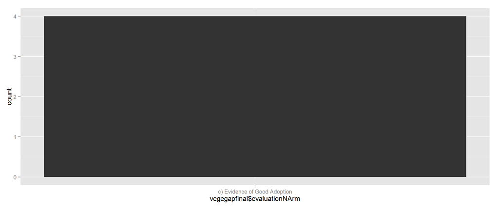

```
## [[1]]
## [[1]][[1]]
##   y count x ndensity ncount  density PANEL group ymin ymax xmin xmax
## 1 4     4 1        1      1 1.111111     1     1    0    4 0.55 1.45
```

```r
ifelse(nrow(vegegapfinal)==0 | all(is.na(vegegapfinal$evaluationNArm)),"No Vegetable Data In Dataset, or all values <NA>",print(ggplot(data=vegegapfinal, aes(vegegapfinal$evaluationNArm)) + geom_histogram() )) #ignore NA
```

```r
ifelse(nrow(vegegapfinal)==0 | all(is.na(vegegapfinal$evaluation)),"No Vegetable Data In Dataset, or all values <NA>",print(
ggplot(data=vegegapfinal, aes(vegegapfinal$evaluation)) + geom_histogram() )) #remove NA casewise
```

```
## [1] "No Vegetable Data In Dataset, or all values <NA>"
```